# Bay-Area Bikeshare Data Exploration

## Author : James Funware West

## Introduction

This data set includes information about individual rides made in a bike-sharing system covering the greater San Francisco Bay area. The data can be gotten from the sources below :

- Website: http://www.bayareabikeshare.com/
- Systems Data Page: http://www.bayareabikeshare.com/open-data
- Data being shared: Trip, Station, Membership, Weather, Bike and Dock Availability

This data is only for the month of February, 2019.

The purpose of this analysis is the understand the behaviour of our users, and point key factors that influence how they use our services. This analysis will focus on `usertypes` to understand how different factors like `time of the day`, `day of the week`, `age`, `gender` affects the duration of user's trip and how often they use the service.

Some of the questions we will be answering are as follows :

- What is the gender proportion of users ?
- What is the proportion of usertypes ?
- What is the age distribution of users ?
- What is the distribution of duration of trips ?
- How long does different usertypes ride ?
- When do different usertypes ride ?
- Why do different usertypes use the service ?

## Preliminary Wrangling

```python
# import all packages and set plots to be embedded inline
import numpy as np
import pandas as pd
import matplotlib.pyplot as plt
import seaborn as sns

%matplotlib inline
```

```python
# Loading the dataset
df = pd.read_csv('201902-fordgobike-tripdata.csv')
```

```python
df.head()
```

|  | duration_sec | start_time | end_time | start_station_id | start_station_name | start_station_latitude | start_station_longitude | end_station_id | end_station_name | end_station_latitude | end_station_longitude | bike_id | user_type | member_birth_year | member_gender | bike_share_for_all_trip |
| --- | --- | --- | --- | --- | --- | --- | --- | --- | --- | --- | --- | --- | --- | --- | --- | --- |
| 0 | 52185 | 2019-02-28 17:32:10.1450 | 2019-03-01 08:01:55.9750 | 21.0 | Montgomery St BART Station (Market St at 2nd St) | 37.789625 | -122.400811 | 13.0 | Commercial St at Montgomery St | 37.794231 | -122.402923 | 4902 | Customer | 1984.0 | Male | No |
| 1 | 42521 | 2019-02-28 18:53:21.7890 | 2019-03-01 06:42:03.0560 | 23.0 | The Embarcadero at Steuart St | 37.791464 | -122.391034 | 81.0 | Berry St at 4th St | 37.775880 | -122.393170 | 2535 | Customer | NaN | NaN | No |
| 2 | 61854 | 2019-02-28 12:13:13.2180 | 2019-03-01 05:24:08.1460 | 86.0 | Market St at Dolores St | 37.769305 | -122.426826 | 3.0 | Powell St BART Station (Market St at 4th St) | 37.786375 | -122.404904 | 5905 | Customer | 1972.0 | Male | No |
| 3 | 36490 | 2019-02-28 17:54:26.0100 | 2019-03-01 04:02:36.8420 | 375.0 | Grove St at Masonic Ave | 37.774836 | -122.446546 | 70.0 | Central Ave at Fell St | 37.773311 | -122.444293 | 6638 | Subscriber | 1989.0 | Other | No |
| 4 | 1585 | 2019-02-28 23:54:18.5490 | 2019-03-01 00:20:44.0740 | 7.0 | Frank H Ogawa Plaza | 37.804562 | -122.271738 | 222.0 | 10th Ave at E 15th St | 37.792714 | -122.248780 | 4898 | Subscriber | 1974.0 | Male | Yes |

```python
# Shape of data
df.shape
```

```
(183412, 16)
```

```python
df.describe()
```

|  | duration_sec | start_station_id | start_station_latitude | start_station_longitude | end_station_id | end_station_latitude | end_station_longitude | bike_id | member_birth_year |
| --- | --- | --- | --- | --- | --- | --- | --- | --- | --- |
| count | 183412.000000 | 183215.000000 | 183412.000000 | 183412.000000 | 183215.000000 | 183412.000000 | 183412.000000 | 183412.000000 | 175147.000000 |
| mean | 726.078435 | 138.590427 | 37.771223 | -122.352664 | 136.249123 | 37.771427 | -122.352250 | 4472.906375 | 1984.806437 |
| std | 1794.389780 | 111.778864 | 0.099581 | 0.117097 | 111.515131 | 0.099490 | 0.116673 | 1664.383394 | 10.116689 |
| min | 61.000000 | 3.000000 | 37.317298 | -122.453704 | 3.000000 | 37.317298 | -122.453704 | 11.000000 | 1878.000000 |
| 25% | 325.000000 | 47.000000 | 37.770083 | -122.412408 | 44.000000 | 37.770407 | -122.411726 | 3777.000000 | 1980.000000 |
| 50% | 514.000000 | 104.000000 | 37.780760 | -122.398285 | 100.000000 | 37.781010 | -122.398279 | 4958.000000 | 1987.000000 |
| 75% | 796.000000 | 239.000000 | 37.797280 | -122.286533 | 235.000000 | 37.797320 | -122.288045 | 5502.000000 | 1992.000000 |
| max | 85444.000000 | 398.000000 | 37.880222 | -121.874119 | 398.000000 | 37.880222 | -121.874119 | 6645.000000 | 2001.000000 |

```python
df.info()
```

```
<class 'pandas.core.frame.DataFrame'>
RangeIndex: 183412 entries, 0 to 183411
Data columns (total 16 columns):
 #   Column                   Non-Null Count   Dtype
---  ------                   --------------   -----
 0   duration_sec             183412 non-null  int64
 1   start_time               183412 non-null  object
 2   end_time                 183412 non-null  object
 3   start_station_id         183215 non-null  float64
 4   start_station_name       183215 non-null  object
 5   start_station_latitude   183412 non-null  float64
 6   start_station_longitude  183412 non-null  float64
 7   end_station_id           183215 non-null  float64
 8   end_station_name         183215 non-null  object
 9   end_station_latitude     183412 non-null  float64
 10  end_station_longitude    183412 non-null  float64
 11  bike_id                  183412 non-null  int64
 12  user_type                183412 non-null  object
 13  member_birth_year        175147 non-null  float64
 14  member_gender            175147 non-null  object
 15  bike_share_for_all_trip  183412 non-null  object
dtypes: float64(7), int64(2), object(7)
memory usage: 22.4+ MB
```

### Data Issues

- `start_time` and `end_time` have datatype as object instead of datetime
- member_birth_year is saved as a float , should be changed to int or dt.year
- Some columns are not needed for our analysis
- Convert `duration_sec` to minutes and rename column as `duration_min`
- Add a `weekday` column
- Add a new column `time_period` indicating time of the day (i.e morning, afternoon, evening)
- Add a new column indicating the age of the customer

> We are interested in finding features that affect trip duration and number of trips

### Data Cleaning

```python
# Making a copy
df_clean = df.copy()
```

#### 1. Change datatype for `start and end time`

`start_time` and `end_time` have datatype as object instead of datetime

```python
## Specifying column to change
ctime = ['start_time','end_time']
## running a loop to change the datatype
for time in ctime:
    df_clean[time] = pd.to_datetime(df_clean[time])
```

```python
# Confirming Change
for time in ctime:
    print(df_clean[time].dtype)
```

```
datetime64[ns]
datetime64[ns]
```

#### 2. Change datatype for `member_birth_year`

`member_birth_year` is saved as a float , should be changed to int

```python
# Changing datatype to a nullable int format
df_clean['member_birth_year'] = df_clean['member_birth_year'].astype('Int64')
```

```python
# Confirming Change
print(df_clean['member_birth_year'].dtype)
```

```
Int64
```

#### 3. Dropping unwanted columns

For this analysis, some columns are not needed

```python
#Checking columns in the dataset
df_clean.columns
```

```
Index(['duration_sec', 'start_time', 'end_time', 'start_station_id',
       'start_station_name', 'start_station_latitude',
       'start_station_longitude', 'end_station_id', 'end_station_name',
       'end_station_latitude', 'end_station_longitude', 'bike_id', 'user_type',
       'member_birth_year', 'member_gender', 'bike_share_for_all_trip'],
      dtype='object')
```

```python
# Specifying columns to be removed
remove= ['bike_id','end_station_longitude','end_station_latitude','end_station_id',
        'start_station_longitude','start_station_latitude','start_station_id']
#drop the listed columns
df_clean.drop(remove,axis=1,inplace=True)
#confirm change
df_clean.columns
```

```
Index(['duration_sec', 'start_time', 'end_time', 'start_station_name',
       'end_station_name', 'user_type', 'member_birth_year', 'member_gender',
       'bike_share_for_all_trip'],
      dtype='object')
```

#### 4. Convert `duration_sec` to minutes and rename as `duration_min`

```python
# divide seconds by 3600 to convert to hours
df_clean['duration_min'] = round(df_clean['duration_sec'] / 60, 2)
#drop duration_sec column
df_clean.drop('duration_sec', axis = 1,inplace=True)
#confirm change
df_clean.head()
```

|  | start_time | end_time | start_station_name | end_station_name | user_type | member_birth_year | member_gender | bike_share_for_all_trip | duration_min |
| --- | --- | --- | --- | --- | --- | --- | --- | --- | --- |
| 0 | 2019-02-28 17:32:10.145 | 2019-03-01 08:01:55.975 | Montgomery St BART Station (Market St at 2nd St) | Commercial St at Montgomery St | Customer | 1984 | Male | No | 869.75 |
| 1 | 2019-02-28 18:53:21.789 | 2019-03-01 06:42:03.056 | The Embarcadero at Steuart St | Berry St at 4th St | Customer | <NA> | NaN | No | 708.68 |
| 2 | 2019-02-28 12:13:13.218 | 2019-03-01 05:24:08.146 | Market St at Dolores St | Powell St BART Station (Market St at 4th St) | Customer | 1972 | Male | No | 1030.90 |
| 3 | 2019-02-28 17:54:26.010 | 2019-03-01 04:02:36.842 | Grove St at Masonic Ave | Central Ave at Fell St | Subscriber | 1989 | Other | No | 608.17 |
| 4 | 2019-02-28 23:54:18.549 | 2019-03-01 00:20:44.074 | Frank H Ogawa Plaza | 10th Ave at E 15th St | Subscriber | 1974 | Male | Yes | 26.42 |

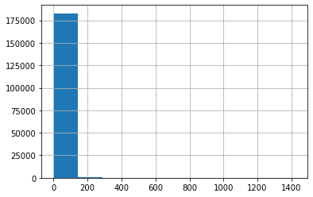

```python
df_clean.duration_min.hist();
```

> We have durations even up to 1400 mins(24 hrs), these may be cases of bike not properly docked or stolen bikes. Let's subset the data to where the bulk of activity is.

```python
df_clean.duration_min.quantile(0.992)
```

```
43.25
```

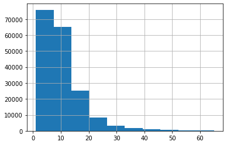

```python
# subsetting the data to only duration equalling 65 and below
df_clean = df_clean[df_clean.duration_min <= 65].reset_index(drop=True)
df_clean.duration_min.hist();
```

#### 5. Add `start_weekday` column

```python
#converting datetime to weekday
df_clean['start_weekday']= df_clean.start_time.dt.day_name()
#confirming change
df_clean.start_weekday.unique()
```

```
array(['Thursday', 'Wednesday', 'Tuesday', 'Monday', 'Sunday', 'Saturday',
       'Friday'], dtype=object)
```

```python
#make this a ordered category
df_clean['start_weekday'] = pd.Categorical(df_clean['start_weekday'],
                                         ['Monday','Tuesday','Wednesday','Thursday','Friday','Saturday','Sunday'])
df_clean['start_weekday'].unique()
```

```
['Thursday', 'Wednesday', 'Tuesday', 'Monday', 'Sunday', 'Saturday', 'Friday']
Categories (7, object): ['Monday', 'Tuesday', 'Wednesday', 'Thursday', 'Friday', 'Saturday', 'Sunday']
```

#### 6. Add `time_period` column

Add a column stating time periods: Morning, afternoon, evening

```python
#create a function for the new column creation
def timep(x):
    if x.hour <= 12:
        return 'Morning'
    elif x.hour > 12 and x.hour <= 16:
        return 'Afternoon'
    else:
        return 'Evening'
```

```python
# Apply the function
df_clean['time_period'] = df_clean['start_time'].apply(timep)
```

```python
# Confirm if the function worked as planned
df_clean[['start_time','time_period']].sample(10)
```

|  | start_time | time_period |
| --- | --- | --- |
| 130414 | 2019-02-09 11:27:09.766 | Morning |
| 114028 | 2019-02-12 09:02:36.119 | Morning |
| 23247 | 2019-02-25 20:40:46.182 | Evening |
| 54677 | 2019-02-21 10:45:25.985 | Morning |
| 5273 | 2019-02-28 13:28:18.032 | Afternoon |
| 89714 | 2019-02-16 11:51:23.278 | Morning |
| 102569 | 2019-02-14 12:14:50.398 | Morning |
| 121409 | 2019-02-11 11:41:02.454 | Morning |
| 89001 | 2019-02-16 14:20:55.735 | Afternoon |
| 62786 | 2019-02-20 15:21:48.605 | Afternoon |

#### 7. Add `customer_age` column

Add a column stating the customer's age.

```python
#defining the current year
year = 2019
df_clean['customer_age'] = year - df_clean.member_birth_year
```

```python
# checking the data type
df_clean.customer_age.dtype
```

```
Int64Dtype()
```

```python
# Confirm Addition
df_clean.head()
```

|  | start_time | end_time | start_station_name | end_station_name | user_type | member_birth_year | member_gender | bike_share_for_all_trip | duration_min | start_weekday | time_period | customer_age |
| --- | --- | --- | --- | --- | --- | --- | --- | --- | --- | --- | --- | --- |
| 0 | 2019-02-28 23:54:18.549 | 2019-03-01 00:20:44.074 | Frank H Ogawa Plaza | 10th Ave at E 15th St | Subscriber | 1974 | Male | Yes | 26.42 | Thursday | Evening | 45 |
| 1 | 2019-02-28 23:49:58.632 | 2019-03-01 00:19:51.760 | 4th St at Mission Bay Blvd S | Broadway at Kearny | Subscriber | 1959 | Male | No | 29.88 | Thursday | Evening | 60 |
| 2 | 2019-02-28 23:55:35.104 | 2019-03-01 00:14:42.588 | Palm St at Willow St | San Jose Diridon Station | Subscriber | 1983 | Female | No | 19.12 | Thursday | Evening | 36 |
| 3 | 2019-02-28 23:41:06.766 | 2019-03-01 00:08:02.756 | Washington St at Kearny St | Valencia St at 21st St | Subscriber | 1989 | Male | No | 26.92 | Thursday | Evening | 30 |
| 4 | 2019-02-28 23:41:48.790 | 2019-03-01 00:07:59.715 | Washington St at Kearny St | Valencia St at 21st St | Subscriber | 1988 | Other | No | 26.17 | Thursday | Evening | 31 |

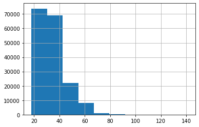

```python
df_clean.customer_age.hist();
```

> We have ages up to 140 in our dataset, let's limit it to age 70

```python
# subsetting the data to only those aged 70 and below
df_clean = df_clean[df_clean.customer_age <= 70]
df_clean.describe()
```

|  | member_birth_year | duration_min | customer_age |
| --- | --- | --- | --- |
| count | 173339.000000 | 173339.000000 | 173339.000000 |
| mean | 1984.969164 | 10.359713 | 34.030836 |
| std | 9.709561 | 7.552664 | 9.709561 |
| min | 1949.000000 | 1.020000 | 18.000000 |
| 25% | 1980.000000 | 5.370000 | 27.000000 |
| 50% | 1987.000000 | 8.470000 | 32.000000 |
| 75% | 1992.000000 | 13.020000 | 39.000000 |
| max | 2001.000000 | 64.970000 | 70.000000 |

```python
# Resetting the index
df_clean=df_clean.reset_index(drop = True)
df_clean.head()
```

|  | start_time | end_time | start_station_name | end_station_name | user_type | member_birth_year | member_gender | bike_share_for_all_trip | duration_min | start_weekday | time_period | customer_age |
| --- | --- | --- | --- | --- | --- | --- | --- | --- | --- | --- | --- | --- |
| 0 | 2019-02-28 23:54:18.549 | 2019-03-01 00:20:44.074 | Frank H Ogawa Plaza | 10th Ave at E 15th St | Subscriber | 1974 | Male | Yes | 26.42 | Thursday | Evening | 45 |
| 1 | 2019-02-28 23:49:58.632 | 2019-03-01 00:19:51.760 | 4th St at Mission Bay Blvd S | Broadway at Kearny | Subscriber | 1959 | Male | No | 29.88 | Thursday | Evening | 60 |
| 2 | 2019-02-28 23:55:35.104 | 2019-03-01 00:14:42.588 | Palm St at Willow St | San Jose Diridon Station | Subscriber | 1983 | Female | No | 19.12 | Thursday | Evening | 36 |
| 3 | 2019-02-28 23:41:06.766 | 2019-03-01 00:08:02.756 | Washington St at Kearny St | Valencia St at 21st St | Subscriber | 1989 | Male | No | 26.92 | Thursday | Evening | 30 |
| 4 | 2019-02-28 23:41:48.790 | 2019-03-01 00:07:59.715 | Washington St at Kearny St | Valencia St at 21st St | Subscriber | 1988 | Other | No | 26.17 | Thursday | Evening | 31 |

```python
# save the new dataset to a csv file
df_clean.to_csv('fordbikeshare_clean.csv')
```

## Exploration

Let's make some functions to reduce repititive codes.

```python
# function to create a figure of boxplot and violin plots
def bvp(x, y,title):
    col = sns.color_palette()[0]
    plt.figure(figsize=[20,8])
    plt.subplot(1,2,1)
    sns.boxplot(data = df_clean, x = x, y = y, color = col)
    plt.subplot(1,2,2)
    sns.violinplot(data = df_clean, x = x, y = y, color = col)
    plt.suptitle(title, fontsize = 20);
```

```python
# function for univariate countplots
def ucp(x,title):
    plt.figure(figsize=[10,5])
    col = sns.color_palette()[0]
    sns.countplot(data = df_clean, x= x, color = col)
    plt.title(title, fontsize = 20);


# function for bivariate countplots
def bcp(x,hue,title):
    plt.figure(figsize=[10,5])
    sns.countplot(data = df_clean, x = x,hue=hue)
    plt.title(title, fontsize = 20);
```

#### 1. What is the proportion of usertype ?

```python
# Getting the count for each usertype
usertype = df_clean.user_type.value_counts()
usertype
```

```
Subscriber    157357
Customer       15982
Name: user_type, dtype: int64
```

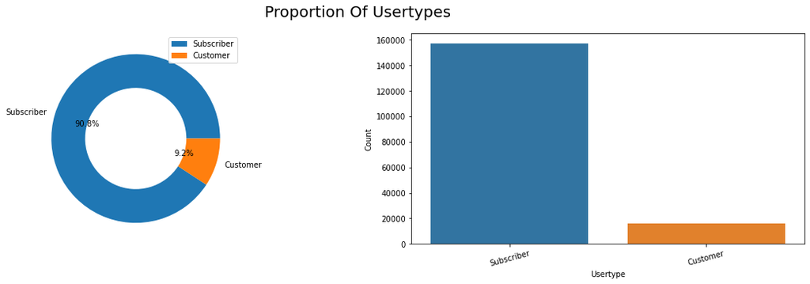

```python
#making the plot
plt.figure(figsize = [20, 5])
plt.suptitle('Proportion Of Usertypes', fontsize = 20)

# pie chart on the left
plt.subplot(1,2,1)
usertype.plot.pie(autopct='%1.1f%%',wedgeprops = {'width' : 0.4})
plt.ylabel('')
plt.legend()

# bar chart on the right
plt.subplot(1,2,2)
sns.countplot(data= df_clean, x = 'user_type', order = usertype.index)
plt.xlabel('Usertype')
plt.ylabel('Count')
plt.xticks(rotation = 15);
```

##### OBSERVATIONS

1. 90.8% of the users are subscribers, while 9.2% are customers. Most of our users are subscribers

#### 2. What is the age distribution of customers?

```python
# Checking age distribution of the customers
df_clean.customer_age.describe()
```

```
count    173339.000000
mean         34.030836
std           9.709561
min          18.000000
25%          27.000000
50%          32.000000
75%          39.000000
max          70.000000
Name: customer_age, dtype: float64
```

```python
#drop rows where age is null
age = df_clean.customer_age.dropna()
```

```python
binedges = np.arange(age.min() - 2, age.max() +2, 2)
```

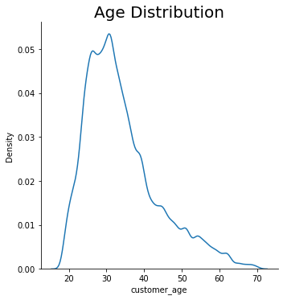

```python
#making the plot
# kernel density estimate plot
sns.displot(x = age,kind = 'kde')
plt.title('Age Distribution', fontsize = 20);
```

The above plot shows that most customers are between the age 25 and 40.

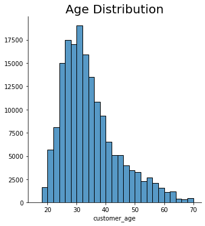

```python
#making the plot
# histogram
sns.displot(x = age,kind = 'hist', bins = binedges)
plt.ylabel('')
plt.title('Age Distribution', fontsize = 20);
```

##### OBSERVATIONS

The distribution is right skewed, most of our customers are between the age 25 and 40. This might imply that most of our customers use our bikeshare services to get to work. Let's check out the number of trips for each hour of the day.

#### 3. How many trips are started for each hour of the day ?

```python
# getting the start hour for each trip
df_clean['start_hour'] = df_clean.start_time.apply(lambda x: x.hour)
```

```python
# confirming correct addition
df_clean.sample(5)
```

|  | start_time | end_time | start_station_name | end_station_name | user_type | member_birth_year | member_gender | bike_share_for_all_trip | duration_min | start_weekday | time_period | customer_age | start_hour |
| --- | --- | --- | --- | --- | --- | --- | --- | --- | --- | --- | --- | --- | --- |
| 160805 | 2019-02-04 08:33:36.915 | 2019-02-04 08:46:42.063 | The Embarcadero at Sansome St | Civic Center/UN Plaza BART Station (Market St ... | Subscriber | 1984 | Female | No | 13.08 | Monday | Morning | 35 | 8 |
| 60366 | 2019-02-20 13:59:56.817 | 2019-02-20 14:07:01.922 | Powell St BART Station (Market St at 5th St) | Market St at 10th St | Subscriber | 2000 | Female | No | 7.08 | Wednesday | Afternoon | 19 | 13 |
| 61640 | 2019-02-20 10:10:04.457 | 2019-02-20 10:13:14.743 | 5th St at San Salvador St | Paseo De San Antonio at 2nd St | Subscriber | 1993 | Male | Yes | 3.17 | Wednesday | Morning | 26 | 10 |
| 55720 | 2019-02-20 22:17:58.298 | 2019-02-20 22:23:50.670 | San Salvador St at 9th St | Pierce Ave at Market St | Subscriber | 1993 | Male | Yes | 5.87 | Wednesday | Evening | 26 | 22 |
| 51613 | 2019-02-21 12:26:08.431 | 2019-02-21 12:46:12.555 | 2nd St at Townsend St | McCoppin St at Valencia St | Subscriber | 1993 | Other | No | 20.07 | Thursday | Morning | 26 | 12 |

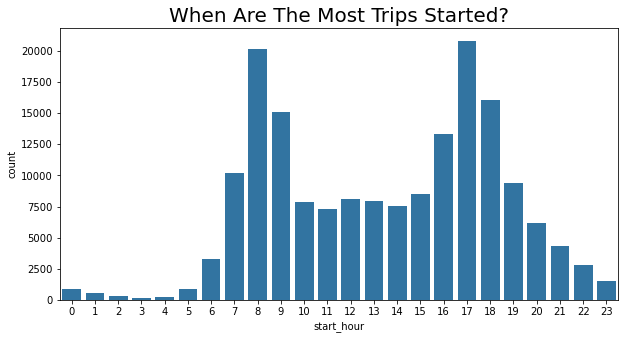

```python
ucp('start_hour','When Are The Most Trips Started?')
```

##### OBSERVATIONS

> Bike share sees spike in usage at rush hours of 7-9 and 16 - 18. This agrees with our previous assumption that most of our customers use our bikeshare services to get to work. Let's go further and see usertype activities during various hours of the day.

#### 4. How many trips are started for each hour of the day by each usertype ?

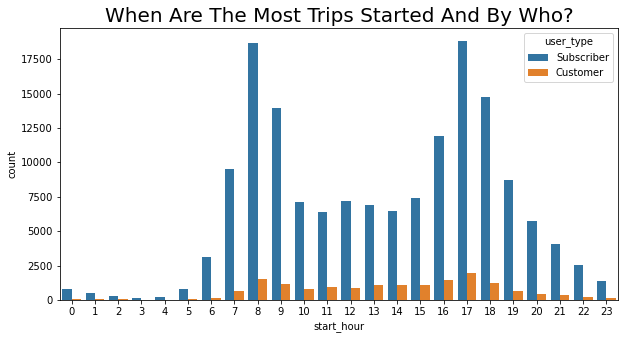

```python
bcp('start_hour','user_type','When Are The Most Trips Started And By Who?')
```

##### OBSERVATIONS

> It is clearly seen that the spike during rush hour is significantly cause by our subscribers, this inturn confirms that our subscribers use bikeshare for transit to work. Customer's activity remains relatively constant during the day and this goes to show they are for leisure rides.

#### 5. What is the age distribution of different usertypes?

```python
# getting summary statistics of the age of different usertypes
df_clean.groupby('user_type')['customer_age'].describe()
```

| user_type | count | mean | std | min | 25% | 50% | 75% | max |
| --- | --- | --- | --- | --- | --- | --- | --- | --- |
| Customer | 15982.0 | 33.566825 | 9.227547 | 18.0 | 27.0 | 32.0 | 38.0 | 70.0 |
| Subscriber | 157357.0 | 34.077963 | 9.755978 | 18.0 | 27.0 | 32.0 | 39.0 | 70.0 |

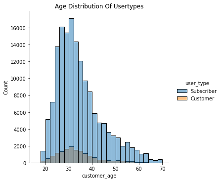

```python
#plotting the age distribution
sns.displot(data= df_clean, hue= 'user_type', x = 'customer_age', kind = 'hist', bins = binedges)
plt.title('Age Distribution Of Usertypes');
```

##### OBSERVATIONS

> There is no clear distinction of the ages of different usertypes, but customers appear to be slightly younger than subscribers

#### 6. What is the gender distribution of customers?

```python
# getting the count for each gender
gender = df_clean.member_gender.value_counts()
gender
```

```
Male      129354
Female     40427
Other       3558
Name: member_gender, dtype: int64
```

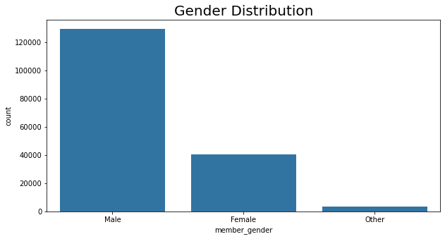

```python
ucp('member_gender','Gender Distribution')
```

##### OBSERVATIONS

> Most customers are males, followed by female and other respectively.

#### 7. What is the distribution of trip duration?

```python
# getting summary statistics for trip duration
df_clean.duration_min.describe()
```

```
count    173339.000000
mean         10.359713
std           7.552664
min           1.020000
25%           5.370000
50%           8.470000
75%          13.020000
max          64.970000
Name: duration_min, dtype: float64
```

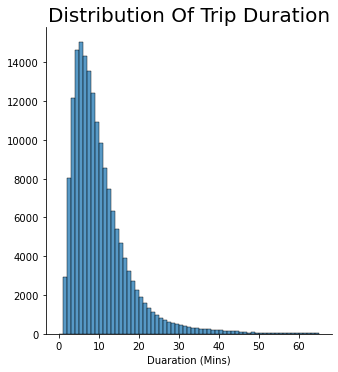

```python
#Making the plot
sns.displot(x = df_clean.duration_min, bins = np.arange(0,df_clean.duration_min.max() + 1, 1), kind = 'hist')
plt.xlabel('Duaration (Mins)')
plt.ylabel('')
plt.title('Distribution Of Trip Duration', fontsize = 20);
```

##### OBSERVATIONS

> Most trips are short trips, usually less than 20 minutes. Let's figure out how long each usertype's trip duration is.

#### 8. Trip Duration For Usertypes

```python
# getting summary statistics for trip duration
df_clean.groupby('user_type').duration_min.describe()
```

| user_type | count | mean | std | min | 25% | 50% | 75% | max |
| --- | --- | --- | --- | --- | --- | --- | --- | --- |
| Customer | 15982.0 | 15.214586 | 10.225789 | 1.03 | 8.13 | 12.63 | 19.25 | 64.82 |
| Subscriber | 157357.0 | 9.866626 | 7.041275 | 1.02 | 5.18 | 8.15 | 12.45 | 64.97 |

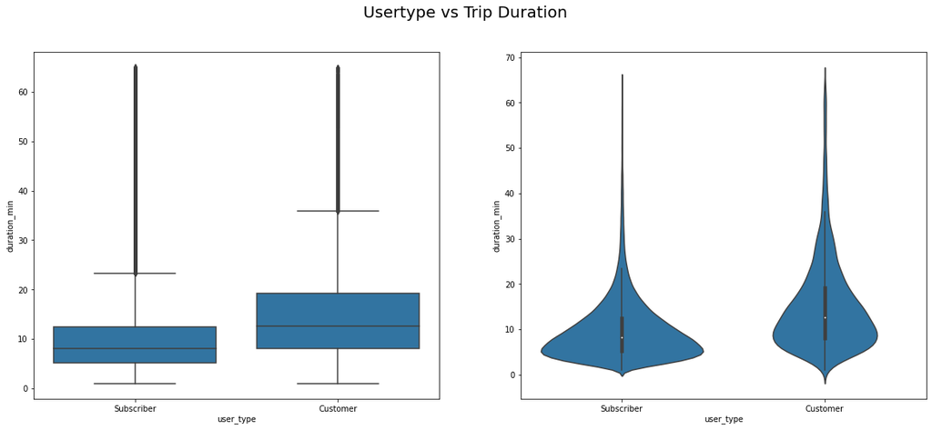

```python
bvp('user_type','duration_min',"Usertype vs Trip Duration")
```

##### OBSERVATIONS

> From the above plots and our previous plots, even if most of our users are subscribers, subscribers use bike share services to get to work and back. This in turn translates to short trips, while customer's usually use the bikeshare service for longer trips most liklely for leisure.

#### 9. Trip Duration For Gender

```python
# getting summary statistics for trip duration
df_clean.groupby('member_gender').duration_min.describe()
```

| member_gender | count | mean | std | min | 25% | 50% | 75% | max |
| --- | --- | --- | --- | --- | --- | --- | --- | --- |
| Female | 40427.0 | 11.315868 | 7.944221 | 1.02 | 5.9800 | 9.400 | 14.23 | 64.82 |
| Male | 129354.0 | 10.029162 | 7.348961 | 1.02 | 5.1800 | 8.180 | 12.58 | 64.97 |
| Other | 3558.0 | 11.513041 | 9.099756 | 1.05 | 5.6725 | 9.075 | 14.18 | 64.53 |

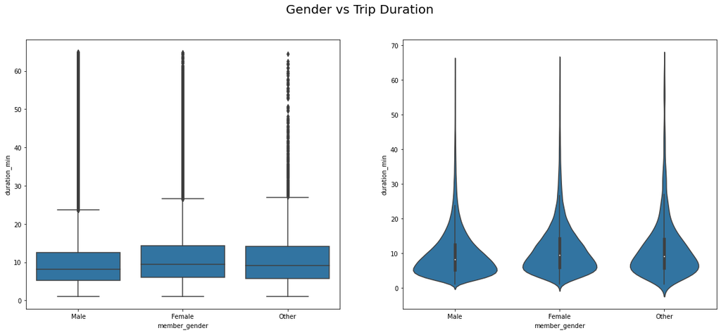

```python
bvp('member_gender','duration_min',"Gender vs Trip Duration")
```

##### OBSERVATIONS

> From the above plots and our previous plots, females and other have a slightly go for longer trips than males. Let's dive in to see what percentage of each usertype constitutes each gender.

#### 10. What is the customer type distribution for each gender ?

```python
# getting the count of customer types for each gender
gen = df_clean.groupby('member_gender')['user_type'].value_counts(normalize = True).mul(100)
gen = gen.round(2).reset_index(name = 'percent')
gen
```

|  | member_gender | user_type | percent |
| --- | --- | --- | --- |
| 0 | Female | Subscriber | 89.02 |
| 1 | Female | Customer | 10.98 |
| 2 | Male | Subscriber | 91.41 |
| 3 | Male | Customer | 8.59 |
| 4 | Other | Subscriber | 87.66 |
| 5 | Other | Customer | 12.34 |

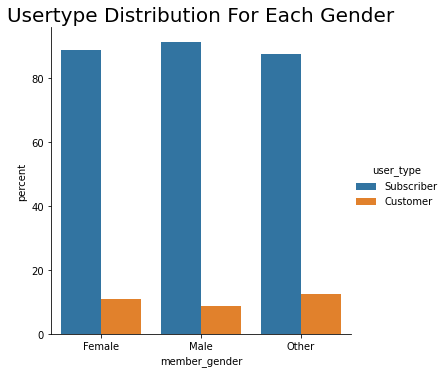

```python
# making the plot
plt.figure(figsize=[10,5])
sns.catplot(data = gen, x= 'member_gender', y= 'percent', hue = 'user_type', kind = 'bar')
plt.title('Usertype Distribution For Each Gender', fontsize = 20);
```

##### OBSERVATIONS

> The percentage of the customer usertype is slightly higher in both female and other, this in turn results in the longer trips in both groups.

#### 11. How many trips were started in each time period ?

```python
# Changing time period to categorical data type
df_clean.time_period = pd.Categorical(df_clean.time_period, ['Morning', 'Afternoon','Evening'])
df_clean.time_period.unique()
```

```
['Evening', 'Afternoon', 'Morning']
Categories (3, object): ['Morning', 'Afternoon', 'Evening']
```

```python
# getting the number of trips for each time period
tp = df_clean.time_period.value_counts(sort = False)
tp
```

```
Morning      74976
Afternoon    37273
Evening      61090
Name: time_period, dtype: int64
```

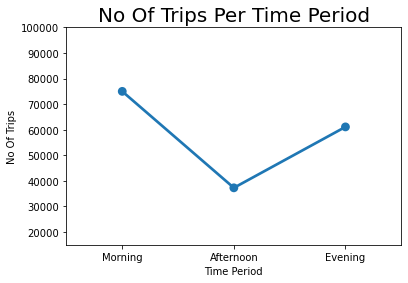

```python
#Making the plot
sns.pointplot(x = tp.index, y = tp.values)
plt.xlabel('Time Period')
plt.ylim(15000, 100000)
plt.ylabel('No Of Trips')
plt.title('No Of Trips Per Time Period', fontsize = 20);
```

##### OBSERVATIONS

> As earlier noted, there's a spike in activity in the morning and in the evening.

#### 12. How many trips started at each station ?

```python
# getting the number of trips for each start station (top 10)
station = df_clean.start_station_name.value_counts()
station = station.nlargest(10)
station
```

```
Market St at 10th St                                         3629
San Francisco Caltrain Station 2  (Townsend St at 4th St)    3378
Berry St at 4th St                                           2914
Montgomery St BART Station (Market St at 2nd St)             2691
Powell St BART Station (Market St at 4th St)                 2579
San Francisco Caltrain (Townsend St at 4th St)               2542
San Francisco Ferry Building (Harry Bridges Plaza)           2494
Howard St at Beale St                                        2207
Steuart St at Market St                                      2166
Powell St BART Station (Market St at 5th St)                 2108
Name: start_station_name, dtype: int64
```

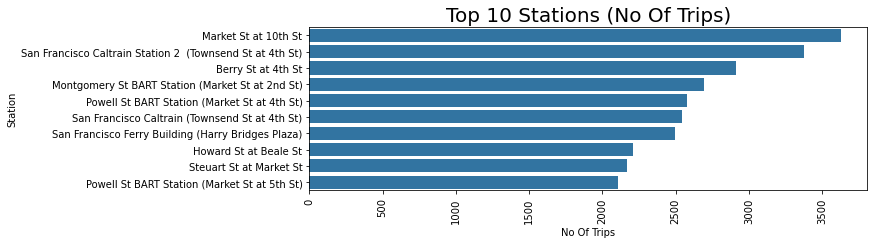

```python
#Making the plot
plt.figure(figsize=[10,3])
sns.countplot(y = df_clean.start_station_name, order = station.index, color = sns.color_palette()[0])
plt.xlabel('No Of Trips')
plt.xticks(rotation = 90)
plt.ylabel('Station')
plt.title('Top 10 Stations (No Of Trips)', fontsize = 20);
```

> Wow! The above shows us some of the busiest stations. Let's look further to know what customer type patronizes these stations the most

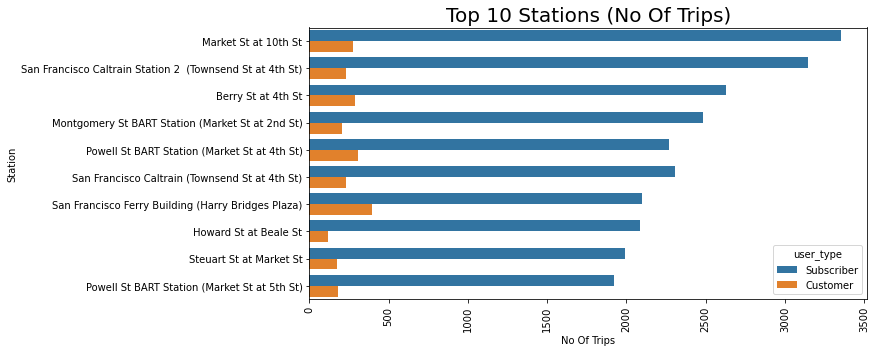

```python
#Making the plot
plt.figure(figsize=[10,5])
sns.countplot(data = df_clean,y = df_clean.start_station_name, hue = 'user_type', order = station.index)
plt.xlabel('No Of Trips')
plt.xticks(rotation = 90)
plt.ylabel('Station')
plt.title('Top 10 Stations (No Of Trips)', fontsize = 20);
```

##### OBSERVATIONS

> `Market St at 10th St.` and `San Francisco Caltrain Station 2 (Townsend St at 4th St)` ranks as the busiest stations. As we would expect, among the top 10 stations most of the users are subscribers but `San Francisco Ferry Building (Harry Bridges Plaza)` is quite popular among customers.

#### 13. How many trips started on each day of the week ?

```python
# getting the number of trips for each day of the week
week = df_clean.start_weekday.value_counts(sort = False)
week.sort_values(ascending= False)
```

```
Thursday     33457
Tuesday      30402
Wednesday    28237
Friday       27425
Monday       25385
Sunday       14227
Saturday     14206
Name: start_weekday, dtype: int64
```

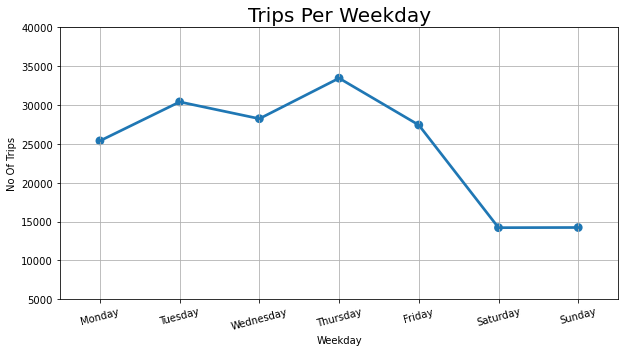

```python
#Making the plot
plt.figure(figsize=[10,5])
sns.pointplot(x= week.index, y = week.values)
plt.xlabel('Weekday')
plt.xticks(rotation = 15)
plt.ylabel('No Of Trips')
plt.grid()
plt.ylim(5000, 40000)
plt.title('Trips Per Weekday', fontsize = 20);
```

The busiest days are weekdays,and usage peaks mid week seeing a decline on weekends.

#### 14. How many trips started on each day of the week by each usertype?

```python
# getting the number of trips for each day of the week
week = df_clean.groupby('user_type').start_weekday.value_counts()
week
```

```
user_type
Customer    Thursday      2791
            Friday        2471
            Tuesday       2237
            Monday        2230
            Sunday        2146
            Saturday      2055
            Wednesday     2052
Subscriber  Thursday     30666
            Tuesday      28165
            Wednesday    26185
            Friday       24954
            Monday       23155
            Saturday     12151
            Sunday       12081
Name: start_weekday, dtype: int64
```

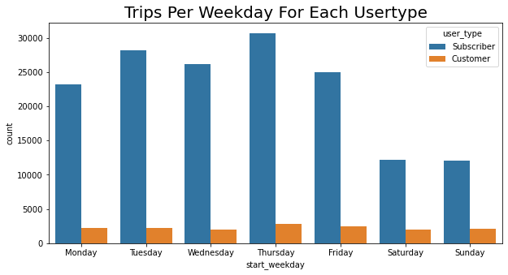

```python
bcp('start_weekday','user_type','Trips Per Weekday For Each Usertype')
```

##### OBSERVATIONS

> The number of trips taken peaks during the week and sharply declines on Saturday and Sunday. Further analysis shows that the behaviour of customers remain relatively constant all week round, but subscribers show a change of behaviour during the weekend. This further reinforces the point that most subscribers use the service for work transit.

#### 15. What is the relationship between age and trip duration ?

```python
# dropping nulls in age and trip duration
atd = df_clean[['customer_age','duration_min']].dropna()
atd.head()
```

|  | customer_age | duration_min |
| --- | --- | --- |
| 0 | 45 | 26.42 |
| 1 | 60 | 29.88 |
| 2 | 36 | 19.12 |
| 3 | 30 | 26.92 |
| 4 | 31 | 26.17 |

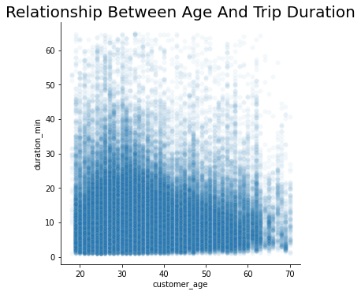

```python
# Making the plot
sns.relplot(data = atd ,x = 'customer_age', y = 'duration_min',alpha = 0.05)
plt.title('Relationship Between Age And Trip Duration', fontsize = 20);
```

##### OBSERVATIONS

> There is no distinct relationship between a customer's age and duration of a trip, but we can see that more elder users go shorter distances as expected.

#### 16. What is the average trip duration per time period for each usertype?

```python
df_clean.groupby(['time_period','user_type'])['duration_min'].mean()
```

```
time_period  user_type
Morning      Customer      14.659671
             Subscriber     9.778741
Afternoon    Customer      17.330600
             Subscriber    10.173752
Evening      Customer      13.972850
             Subscriber     9.795341
Name: duration_min, dtype: float64
```

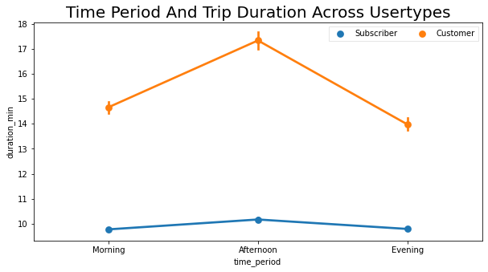

```python
#Making the plot
plt.figure(figsize=[10,5])
sns.pointplot(data = df_clean, x='time_period', y = 'duration_min',
            hue = 'user_type', order = ['Morning', 'Afternoon','Evening'])
plt.title('Time Period And Trip Duration Across Usertypes', fontsize = 20)
plt.legend(loc = 0, framealpha = 0.5, ncol = 3, fancybox = False);
```

##### OBSERVATIONS

> The above plot further explains that casual users go for longer rides than subscribers. It always explains that longer trips happen in the afternoon, and the shorter trips in the morning and evening as already explained are work trips.

```python
df_clean.groupby(['time_period','start_weekday'])['duration_min'].mean().round(2)
```

```
time_period  start_weekday
Morning      Monday            9.92
             Tuesday           9.93
             Wednesday         9.86
             Thursday          9.96
             Friday           10.14
             Saturday         11.37
             Sunday           11.92
Afternoon    Monday           10.96
             Tuesday          10.24
             Wednesday        10.02
             Thursday         10.46
             Friday           10.69
             Saturday         12.53
             Sunday           12.70
Evening      Monday            9.96
             Tuesday           9.84
             Wednesday         9.99
             Thursday         10.34
             Friday           10.15
             Saturday         11.01
             Sunday           10.29
Name: duration_min, dtype: float64
```

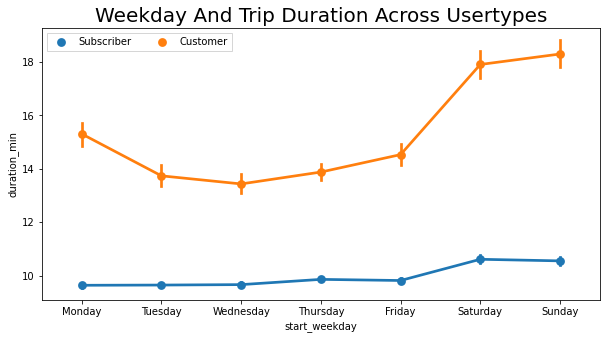

```python
#Making the plot
plt.figure(figsize=[10,5])
sns.pointplot(data = df_clean, x='start_weekday', y = 'duration_min',
            hue = 'user_type')
plt.title('Weekday And Trip Duration Across Usertypes', fontsize = 20)
plt.legend(loc = 0, ncol = 2, fancybox = False);
```

##### OBSERVATIONS

> Both usertypes go for longer trips on weekends, but subscribers maintain a relatively constant trip duration all week while customers see an increase on weekends. This further explains that customers are leisure riders and subscribers use the service for work trips

## Resources

- https://stackoverflow.com/questions/34863363/using-an-if-statement-involving-time-in-python
- https://stackoverflow.com/questions/4362491/how-do-i-check-the-difference-in-seconds-between-two-dates
- https://stackoverflow.com/questions/47333227/pandas-valueerror-cannot-convert-float-nan-to-integer
- https://stackoverflow.com/questions/8380389/how-to-get-day-name-from-datetime
- https://stackoverflow.com/questions/7066121/how-to-set-a-single-main-title-above-all-the-subplots-with-pyplot
- https://seaborn.pydata.org/generated/seaborn.swarmplot.html
- https://www.statology.org/left-skewed-vs-right-skewed/
- https://stackoverflow.com/questions/32891211/limit-the-number-of-groups-shown-in-seaborn-countplot
- https://stackoverflow.com/questions/59602604/round-off-to-decimal-places-within-aggregate-of-groupby-pandas-python
- https://stackoverflow.com/questions/34615854/seaborn-countplot-with-normalized-y-axis-per-group
- https://matplotlib.org/stable/api/_as_gen/matplotlib.pyplot.legend.html
- https://jakevdp.github.io/PythonDataScienceHandbook/04.06-customizing-legends.html